# Part II - (Prosper Loan- Explanatory Analysis)

## by (Quadri Omotesho)

## Investigation Overview

> In this investigation, I will like to examine the features of the datasets that affect significantly affects the Borrower's Interest rate. I will also like to compare the influence of these features on the original loan amount given to borrowers. Some relationships that I will be exploring include: BorrowerRate Vs ProsperRating, Loan Original Amount Vs ProsperRating, and then a combination of the three variables.

## Dataset Overview

> The data set is named Prosper Loan Data. There are 113937 rows and 81 columns in the dataset. It is a datasets showing information about the borrowers and lenders of loan. For my analysis, I created a subset of the data set as I was interested in some columns in the data set. This new subset(loan_subs) has 84853 rows and 11 columns. The columns that make this subset are; numeric variables = BorrowerRate, LoanOriginalAmount, DebtToIncomeRatio cat_var = LoanStatus, Income_range, EmploymentStatus, Terms, ProsperRating, IsBorrowerHomeowner,ListingCategory

## (Borrower Interest Rate Disribution)

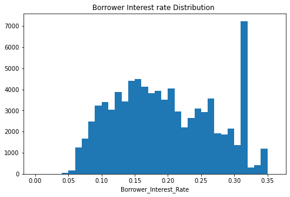

## (Original Loan Amount Distribution)

> The Original Loan amount is the amount of loan first colleceted by the borrower.
> - From the loan Amount Distribution Plot, we can see that the most popular amounts are 4,000, 10,000 and 15,000 dollars. The upper limit is 35,000 dollars while the lower limit is 1,000 dollars. The most given out loan amount is 4,000 dollars. The log transformation of the scale was done to improve visuals.

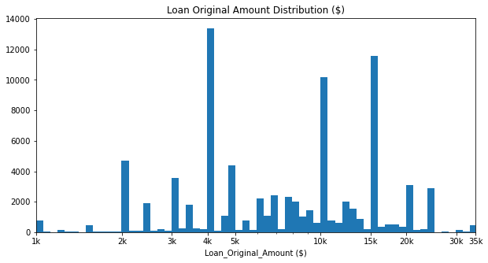

## (Prosper Rating Distribution)

> The Prosper Rating is assigned at the time the listing was created between AA-HR with AA being the highest and HR being the lowest.
> - From the plot of the Prosper Rating Distribution, we can observe that most loans were given to the individual with ratings of D and above as expected. The prosper rating could be a major determinant if a person will get a loan and it could also predict interest rate.

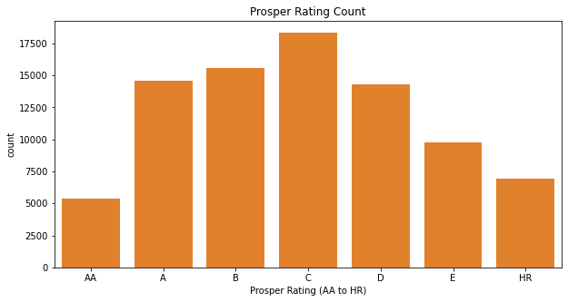

## (Prosper Rating Vs Borrower Rate) and (Prosper Rating Vs Original Loan Amount)

> From the plot above, we can see that the Prosper Rating is a good predictor of the Borrower Interest rate and the initial loan amount given.
> - It is obvious that borrowers with high prosper rating (AA) have a good loan history and thus receive lower interest rate.They are also qualified for higher amount of loan.
> - Individuals with lower prosper rating (HR) do not have such history, hence higher interest rate and low loan amount.

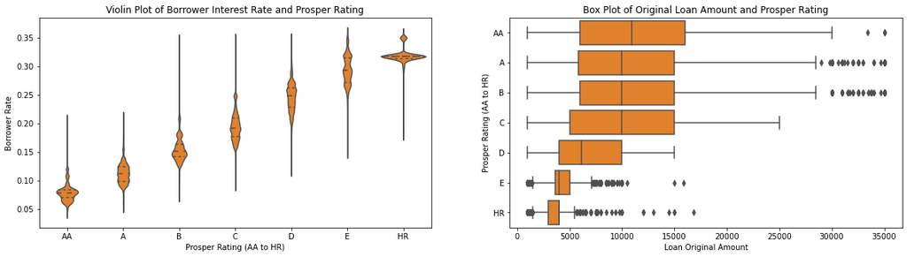

## Prosper Rating Vs Borrower Rate Vs Original Loan Amount

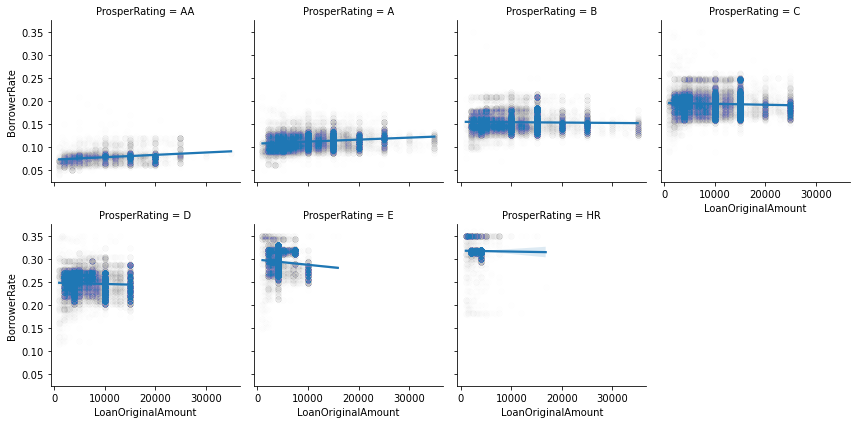